# PISA 2012 Test Data Exploration: A Focus on Family-based Factors

## by Yan LU

## Investigation Overview

> In this study, I wanted to look at the effects of family-based factors on the students' academic performance. The factors to be investigated are: language at home, household possessions, family status, parents' working status, and parents' education levels. We are also interested to see if the effects identified are valid across countries.

## Dataset Overview

> Around 510,000 students in 65 economies took part in the PISA 2012 assessment of reading, mathematics and science representing about 28 million 15-year-olds globally. Of those economies, 44 took part in an assessment of creative problem solving and 18 in an assessment of financial literacy. The provided dataset consisted of *485490* observations with *636* variables.

## Distribution of Scores across Countries

- Most countries ranking from 10th to 40th seem to perform comparably to each other.
- Top players outperform significantly over the other countries.
- The outliers of each subject come from different countries.

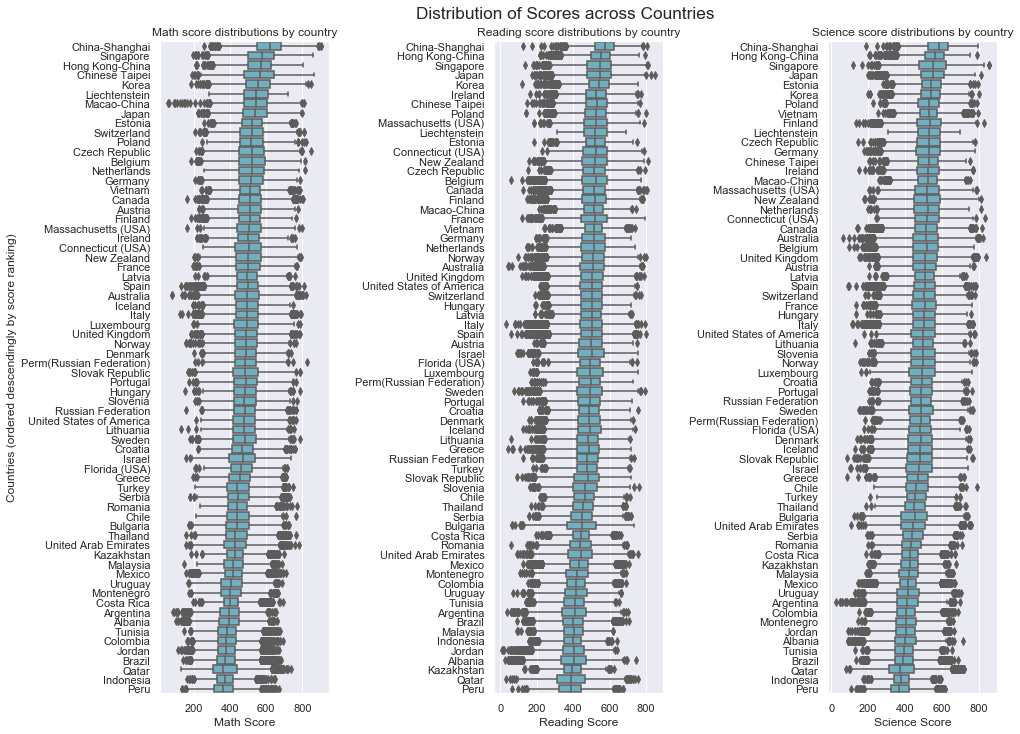

```python
plt.figure(figsize = [15,12])
plt.subplots_adjust(wspace = 0.98) # adjust spacing between subplots, in order to show long country names nicely
plt.suptitle('Distribution of Scores across Countries', y = 0.92 , fontsize = 'xx-large')
math_score_country_order = pisa_home_clean.groupby('Country')['Math_score'].mean().sort_values(ascending = False).index
reading_score_country_order = pisa_home_clean.groupby('Country')['Reading_score'].mean().sort_values(ascending = False).index
science_score_country_order = pisa_home_clean.groupby('Country')['Science_score'].mean().sort_values(ascending = False).index

plt.subplot(1, 3, 1)
sb.boxplot(data = pisa_home_clean, x = 'Math_score', y = 'Country', order = math_score_country_order, color = sb.color_palette()[9]);
plt.ylabel('Countries (ordered descendingly by score ranking)')
plt.xlabel('Math Score')
plt.title('Math score distributions by country');

plt.subplot(1, 3, 2)
sb.boxplot(data = pisa_home_clean, x = 'Reading_score', y = 'Country', order = reading_score_country_order, color = sb.color_palette()[9]);
plt.ylabel(''); # Remove the redundant label
plt.xlabel('Reading Score')
plt.title('Reading score distributions by country');

plt.subplot(1, 3, 3)
sb.boxplot(data = pisa_home_clean, x = 'Science_score', y = 'Country', order = science_score_country_order, color = sb.color_palette()[9]);
plt.xlabel('Science Score')
plt.ylabel(''); # Remove the redundant label
plt.title('Science score distributions by country');
```

## Language at Home vs. Scores

> Language at home is supposed to influence the test score as students who speak the same language as test language is likely to perform better than students who speak a different language. However, the violin plot shows no significant difference between these two categories.

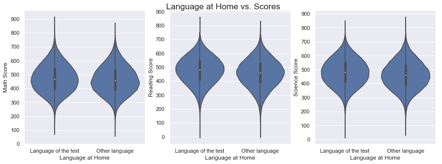

```python
plt.figure(figsize = [15,5])
default_color = sb.color_palette()[0]
bins_hist = np.arange(0, 1000, 100)
plt.suptitle('Language at Home vs. Scores', y = 0.92 , fontsize = 'xx-large')
plt.subplot(1, 3, 1)
sb.violinplot(data = pisa_home_clean, x = 'Language_at_home', y = 'Math_score', color = default_color)
plt.xlabel('Language at Home')
plt.ylabel('Math Score')
plt.yticks(bins_hist);

plt.subplot(1, 3, 2)
sb.violinplot(data = pisa_home_clean, x = 'Language_at_home', y = 'Reading_score', color = default_color)
plt.ylabel('Reading Score')
plt.xlabel('Language at Home')
plt.yticks(bins_hist);

plt.subplot(1, 3, 3)
sb.violinplot(data = pisa_home_clean, x = 'Language_at_home', y = 'Science_score', color = default_color)
plt.ylabel('Science Score')
plt.xlabel('Language at Home')
plt.yticks(bins_hist);
```

## Possession of Books vs. Scores

> Books at home is derived as one of the indicators of household possessions. People tend to believe that people live in a family which has a better educational resource tend to perform better in academic than people who don't.

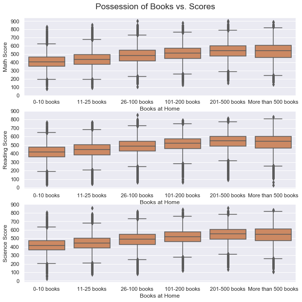

```python
plt.figure(figsize = [10,10])
default_color = sb.color_palette()[1]
bins_hist = np.arange(0, 1000, 100)
plt.suptitle('Possession of Books vs. Scores', y = 0.92 , fontsize = 'xx-large')

plt.subplot(3, 1, 1)
sb.boxplot(data = pisa_home_clean, x = 'Books_at_home', y = 'Math_score', color = default_color)
plt.xlabel('Books at Home')
plt.ylabel('Math Score')
plt.yticks(bins_hist);

plt.subplot(3, 1, 2)
sb.boxplot(data = pisa_home_clean, x = 'Books_at_home', y = 'Reading_score', color = default_color)
plt.xlabel('Books at Home')
plt.ylabel('Reading Score')
plt.yticks(bins_hist);

plt.subplot(3, 1, 3)
sb.boxplot(data = pisa_home_clean, x = 'Books_at_home', y = 'Science_score', color = default_color)
plt.xlabel('Books at Home')
plt.ylabel('Science Score')
plt.yticks(bins_hist);
```

## Family Status vs. Scores

> In this study, we define the family status as whether the participants live in a two-parents family, one parents family (live with mother only/live with father only), or no parents family. We are interested to see if the family status is an important predictors of academic achievement.

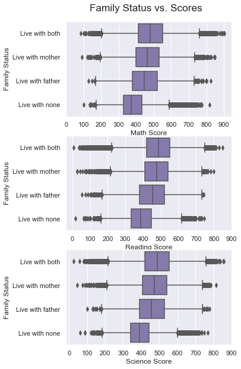

```python
plt.figure(figsize = [5,10])
default_color = sb.color_palette()[4]
bins_hist = np.arange(0, 1000, 100)
plt.suptitle('Family Status vs. Scores', y = 0.92 , fontsize = 'xx-large')
plt.subplot(3, 1, 1)
sb.boxplot(data = pisa_home_clean, y = 'Family_status', x = 'Math_score', color = default_color)
plt.xlabel('Math Score')
plt.ylabel('Family Status')
plt.xticks(bins_hist);

plt.subplot(3, 1, 2)
sb.boxplot(data = pisa_home_clean, y = 'Family_status', x = 'Reading_score', color = default_color)
plt.xlabel('Reading Score')
plt.ylabel('Family Status')
plt.xticks(bins_hist);

plt.subplot(3, 1, 3)
sb.boxplot(data = pisa_home_clean, y = 'Family_status', x = 'Science_score', color = default_color)
plt.xlabel('Science Score')
plt.ylabel('Family Status')
plt.xticks(bins_hist);
```

## Parents Employment Status vs. Score

> Students with fully employed parents do better in tests. Having a mother who works part-time or full-time is associated with test outcomes. Students with a father employed less than full-time have lower test scores than if the father had a full-time postion. A stay-at-home (Other) parent does not improve scores. It will be interesting to see if the finding is consistent across different countries.

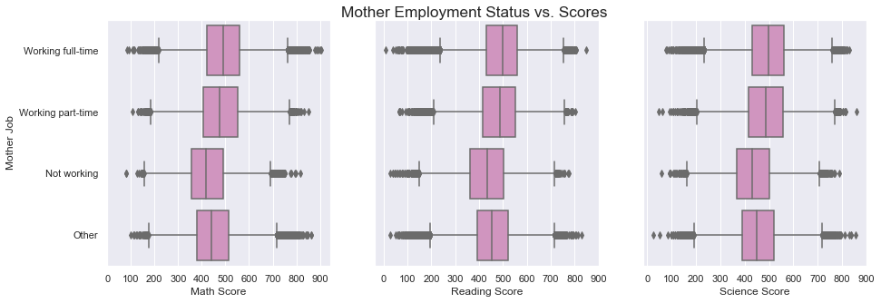

```python
plt.figure(figsize = [15,5])
job_color = sb.color_palette()[6]
bins_hist = np.arange(0, 1000, 100)
plt.suptitle('Mother Employment Status vs. Scores', y = 0.92 , fontsize = 'xx-large')

plt.subplot(1, 3, 1)
sb.boxplot(data = pisa_home_clean, y = 'Mother_job', x = 'Math_score', color = job_color)
plt.yticks(np.arange(4),['Working full-time','Working part-time','Not working','Other'])
plt.xlabel('Math Score')
plt.ylabel('Mother Job')
plt.xticks(bins_hist);

plt.subplot(1, 3, 2)
sb.boxplot(data = pisa_home_clean, y = 'Mother_job', x = 'Reading_score', color = job_color)
plt.xticks(bins_hist)
plt.xlabel('Reading Score')
plt.yticks([])
plt.ylabel('');

plt.subplot(1, 3, 3)
sb.boxplot(data = pisa_home_clean, y = 'Mother_job', x = 'Science_score', color = job_color)
plt.xticks(bins_hist)
plt.xlabel('Science Score')
plt.yticks([])
plt.ylabel('');
```

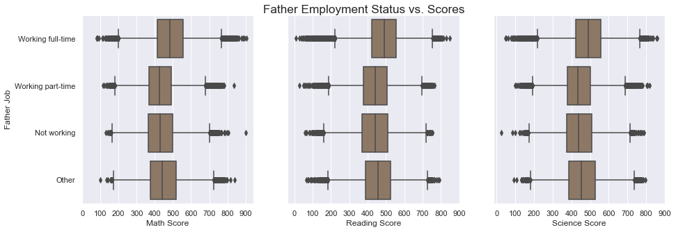

```python
plt.figure(figsize = [15,5])
job_color = sb.color_palette()[5]
bins_hist = np.arange(0, 1000, 100)
plt.suptitle('Father Employment Status vs. Scores', y = 0.92 , fontsize = 'xx-large')

plt.subplot(1, 3, 1)
sb.boxplot(data = pisa_home_clean, y = 'Father_job', x = 'Math_score', color = job_color)
plt.yticks(np.arange(4),['Working full-time','Working part-time','Not working','Other'])
plt.xlabel('Math Score')
plt.ylabel('Father Job')
plt.xticks(bins_hist);

plt.subplot(1, 3, 2)
sb.boxplot(data = pisa_home_clean, y = 'Father_job', x = 'Reading_score', color = job_color)
plt.xticks(bins_hist)
plt.xlabel('Reading Score')
plt.yticks([])
plt.ylabel('');

plt.subplot(1, 3, 3)
sb.boxplot(data = pisa_home_clean, y = 'Father_job', x = 'Science_score', color = job_color)
plt.xticks(bins_hist)
plt.xlabel('Science Score')
plt.yticks([])
plt.ylabel('');
```

## Parents Education Level vs. Scores

> Students with higher educated parents do better in tests. Students with one or two parents whose whose education level equal or higher than ISCED 5A,6 have the highest scores. The difference between ISCED 3B,C and ISCED 3A,4 is not significant.

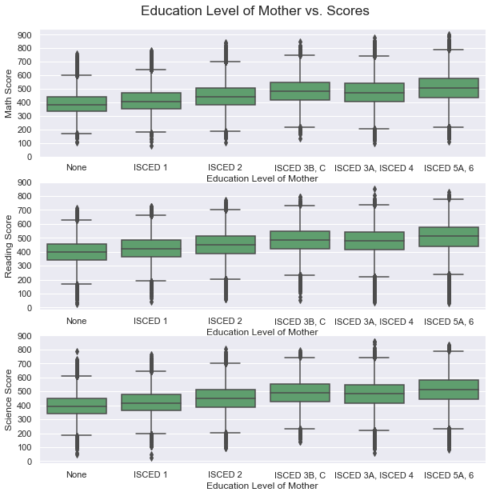

```python
plt.figure(figsize = [10,10])
default_color = sb.color_palette()[2]
bins_hist = np.arange(0, 1000, 100)
plt.suptitle('Education Level of Mother vs. Scores', y = 0.92 , fontsize = 'xx-large')

plt.subplot(3, 1, 1)
sb.boxplot(data = pisa_home_clean, x = 'Edu_level_mother', y = 'Math_score', color = default_color)
plt.xlabel('Education Level of Mother')
plt.ylabel('Math Score')
plt.yticks(bins_hist);

plt.subplot(3, 1, 2)
sb.boxplot(data = pisa_home_clean, x = 'Edu_level_mother', y = 'Reading_score', color = default_color)
plt.xlabel('Education Level of Mother')
plt.ylabel('Reading Score')
plt.yticks(bins_hist);

plt.subplot(3, 1, 3)
sb.boxplot(data = pisa_home_clean, x = 'Edu_level_mother', y = 'Science_score', color = default_color)
plt.xlabel('Education Level of Mother')
plt.ylabel('Science Score')
plt.yticks(bins_hist);
```

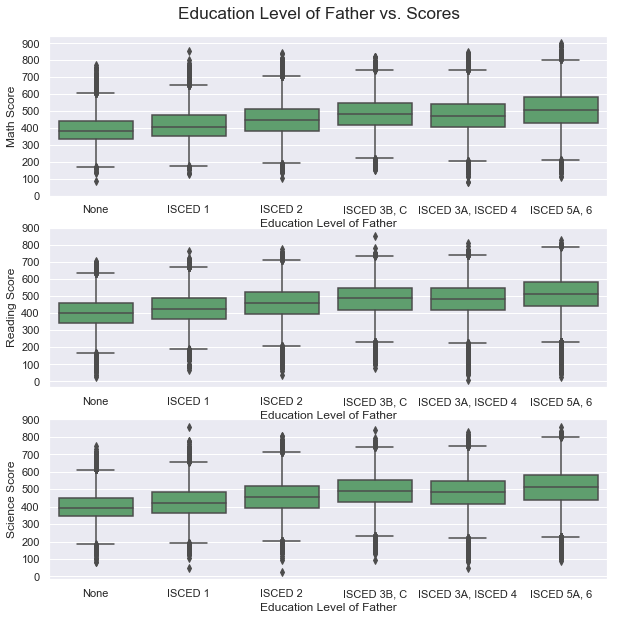

```python
plt.figure(figsize = [10,10])
default_color = sb.color_palette()[2]
bins_hist = np.arange(0, 1000, 100)
plt.suptitle('Education Level of Father vs. Scores', y = 0.92 , fontsize = 'xx-large')

plt.subplot(3, 1, 1)
sb.boxplot(data = pisa_home_clean, x = 'Edu_level_father', y = 'Math_score', color = default_color)
plt.xlabel('Education Level of Father')
plt.ylabel('Math Score')
plt.yticks(bins_hist);

plt.subplot(3, 1, 2)
sb.boxplot(data = pisa_home_clean, x = 'Edu_level_father', y = 'Reading_score', color = default_color)
plt.xlabel('Education Level of Father')
plt.ylabel('Reading Score')
plt.yticks(bins_hist);

plt.subplot(3, 1, 3)
sb.boxplot(data = pisa_home_clean, x = 'Edu_level_father', y = 'Science_score', color = default_color)
plt.xlabel('Education Level of Father')
plt.ylabel('Science Score')
plt.yticks(bins_hist);
```

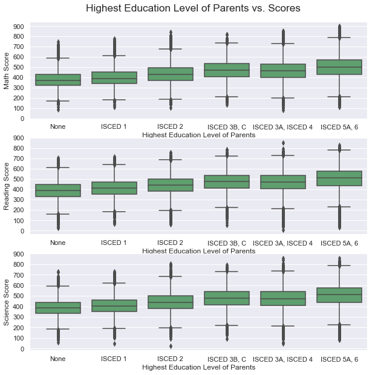

```python
plt.figure(figsize = [10,10])
default_color = sb.color_palette()[2]
bins_hist = np.arange(0, 1000, 100)
plt.suptitle('Highest Education Level of Parents vs. Scores', y = 0.92 , fontsize = 'xx-large')

plt.subplot(3, 1, 1)
sb.boxplot(data = pisa_home_clean, x = 'Highest_edu_level_parents', y = 'Math_score', color = default_color)
plt.xlabel('Highest Education Level of Parents')
plt.ylabel('Math Score')
plt.yticks(bins_hist);

plt.subplot(3, 1, 2)
sb.boxplot(data = pisa_home_clean, x = 'Highest_edu_level_parents', y = 'Reading_score', color = default_color)
plt.xlabel('Highest Education Level of Parents')
plt.ylabel('Reading Score')
plt.yticks(bins_hist);

plt.subplot(3, 1, 3)
sb.boxplot(data = pisa_home_clean, x = 'Highest_edu_level_parents', y = 'Science_score', color = default_color)
plt.xlabel('Highest Education Level of Parents')
plt.ylabel('Science Score')
plt.yticks(bins_hist);
```

## Plot Matrices of Math_score, Reading_score, and Science_score

> There is a strong positive correlation between each pair of the three variables. Therefore, for the following two multivariate analysis, we will only plot the visualizations using Math_score.

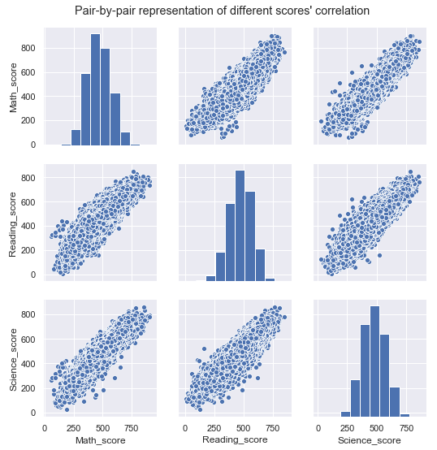

```python
grid = sb.pairplot(data = pisa_home_clean, vars=["Math_score", "Reading_score", "Science_score"]);
grid.fig.suptitle("Pair-by-pair representation of different scores' correlation",  y = 1.02 , fontsize = 'x-large');
```

## Math Score by Family Status and Country

> Students in homes with two parents do better in all three subjects. Exceptions can be observed for Montenegro, Peru, and Vietnam. As observed in bivariate exploration, students with neither parent living at home have the lowest achievement in most countries, except for Estonia, Hong Kong-China, Jordan, Japan, Singapore, Tunisia. The reasons can be explored in future study by taking into account other variables.

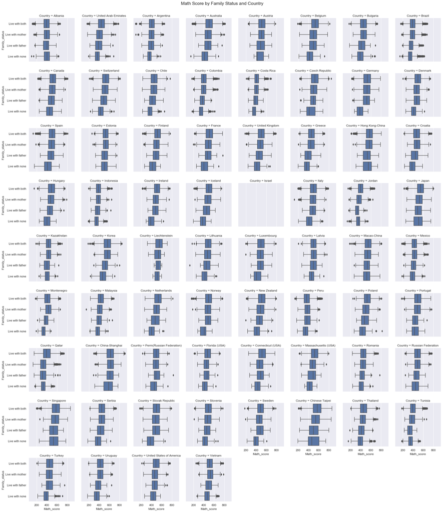

```python
g = sb.FacetGrid(data = pisa_home_clean, col = 'Country', col_wrap = 8)
g.map(sb.boxplot, 'Math_score', 'Family_status')
g.fig.suptitle("Math Score by Family Status and Country", y = 1.02 , fontsize = 'xx-large');
```

## Math Score by Parent Employment Status and Country

> Parent employment status is also an important predictor of academic achievement. The pointplots of math score on this categorical variable across countries indicate that in most countries, students with fully employed fathers do best in tests, while students with fathers who is not working but looking for a job score lowest. Having a mother who works part-time or full-time is associated with high scores, while a stay-at-home (Other) parent does not improve scores. An exception can be observed from Liechtenstein, ranking 6th in math test. In Liechtenstein, the highest scores come from students with non-working mothers or part-time working fathers. Further exploration is required to find out the reason.

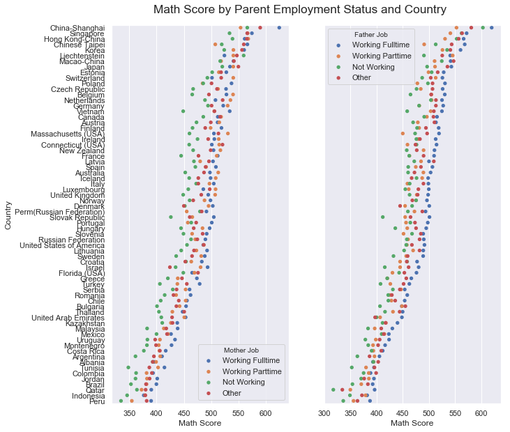

```python
grouped = pisa_home_clean.groupby('Country')['Math_score'].mean()
country_ordered = grouped.sort_values(ascending=False)
country_index= country_ordered.index

plt.figure(figsize = [10,10])
plt.suptitle('Math Score by Parent Employment Status and Country', y = 0.92 , fontsize = 'xx-large')
plt.subplot(1, 2, 1)
ax = sb.pointplot(data = pisa_home_clean, x = 'Math_score', y = 'Country', hue = 'Mother_job', linestyles = "",
                  pallete = 'mako', ci = None, order = country_index, scale = 0.6)
leg_handles = ax.get_legend_handles_labels()[0]
ax.legend(leg_handles, ['Working Fulltime', 'Working Parttime', 'Not Working', 'Other'], title='Mother Job')
plt.xlabel('Math Score');

plt.subplot(1, 2, 2)
ax = sb.pointplot(data = pisa_home_clean, x = 'Math_score', y = 'Country', hue = 'Father_job', linestyles = "",
                  pallete = 'viridis_r', ci = None, order = country_index, scale = 0.6)
leg_handles = ax.get_legend_handles_labels()[0]
ax.legend(leg_handles, ['Working Fulltime', 'Working Parttime', 'Not Working', 'Other'], title='Father Job')
plt.xlabel('Math Score')
plt.yticks([])
plt.ylabel('');
```